# Assessment 1 Part 3

Fatima Aftab 4662948

2022-03-15

**18. Identify variable(s) which should be factors and transform their type into a factor variable.**

```r
library(tidyverse)
library(knitr)
library(skimr)
#install.packages("forcats")
library(forcats)
library(tidyverse)

fastfood <- read_csv('https://raw.githubusercontent.com/rfordatascience/tidytuesday/master/data/2018/2018-09-04/fastfood_calories.csv')
```

```
## * `` -> ...1
```

```r
is.factor(fastfood$restaurant)
```

```
## [1] FALSE
```

```r
as.factor(fastfood$restaurant)
```

```
##   [1] Mcdonalds   Mcdonalds   Mcdonalds   Mcdonalds   Mcdonalds   Mcdonalds
##   [7] Mcdonalds   Mcdonalds   Mcdonalds   Mcdonalds   Mcdonalds   Mcdonalds
##  [13] Mcdonalds   Mcdonalds   Mcdonalds   Mcdonalds   Mcdonalds   Mcdonalds
##  [19] Mcdonalds   Mcdonalds   Mcdonalds   Mcdonalds   Mcdonalds   Mcdonalds
##  [25] Mcdonalds   Mcdonalds   Mcdonalds   Mcdonalds   Mcdonalds   Mcdonalds
##  [31] Mcdonalds   Mcdonalds   Mcdonalds   Mcdonalds   Mcdonalds   Mcdonalds
##  [37] Mcdonalds   Mcdonalds   Mcdonalds   Mcdonalds   Mcdonalds   Mcdonalds
##  [43] Mcdonalds   Mcdonalds   Mcdonalds   Mcdonalds   Mcdonalds   Mcdonalds
##  [49] Mcdonalds   Mcdonalds   Mcdonalds   Mcdonalds   Mcdonalds   Mcdonalds
##  [55] Mcdonalds   Mcdonalds   Mcdonalds   Chick Fil-A Chick Fil-A Chick Fil-A
##  [61] Chick Fil-A Chick Fil-A Chick Fil-A Chick Fil-A Chick Fil-A Chick Fil-A
##  [67] Chick Fil-A Chick Fil-A Chick Fil-A Chick Fil-A Chick Fil-A Chick Fil-A
##  [73] Chick Fil-A Chick Fil-A Chick Fil-A Chick Fil-A Chick Fil-A Chick Fil-A
##  [79] Chick Fil-A Chick Fil-A Chick Fil-A Chick Fil-A Chick Fil-A Chick Fil-A
##  [85] Sonic       Sonic       Sonic       Sonic       Sonic       Sonic
```

[output cut: 72 more lines]

**19. Create two new variables: Read about `cut_number()` function using Help and add a new variable to the dataset `calories_type`. Use `calories` variable for `cut_number()` function to split it into 3 categories `n=3`, add labels `labels=c("low", "med", "high")` and make the dataset ordered by arranging it according to calories. Do not forget to save the updated dataset.**

```r
calories_type <- fastfood %>%
  group_by(restaurant) %>%
  mutate(calories_type = cut_number(calories, n = 3, labels = c("low","med","high"))) %>%
  ungroup() %>%
  arrange(calories_type)

head(calories_type) %>%
       select(restaurant,item,calories,calories_type)
```

```
## # A tibble: 6 × 4
##   restaurant item                             calories calories_type
##   <chr>      <chr>                               <dbl> <fct>
## 1 Mcdonalds  Artisan Grilled Chicken Sandwich      380 low
## 2 Mcdonalds  Cheeseburger                          300 low
## 3 Mcdonalds  Double Cheeseburger                   430 low
## 4 Mcdonalds  Filet-O-Fish®                         380 low
## 5 Mcdonalds  Hamburger                             250 low
## 6 Mcdonalds  Lobster Roll                          290 low
```

**20. Create a dataviz that shows the distribution of `calories_type` in food items for each type of restaurant. Think carefully about the choice of data viz. Use facets, coordinates and theme layers to make your data viz visually appealing and meaningful. Use factors related data viz functions.**

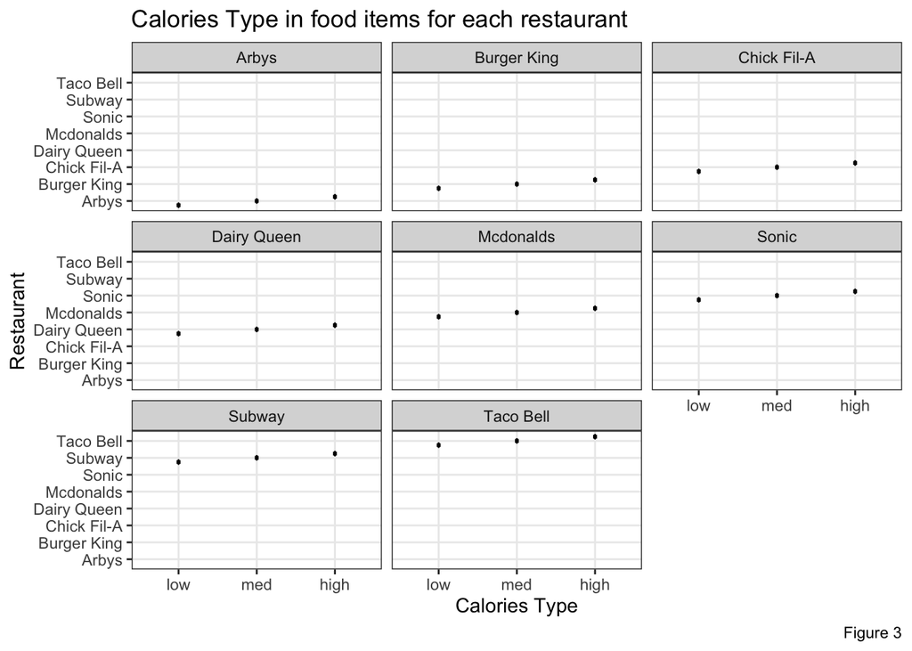

```r
calories_type %>%
  group_by(restaurant) %>%
  ungroup() %>%
  ggplot(aes(restaurant, calories_type)) +
  geom_boxplot(colour="black") +
  facet_wrap(vars(restaurant)) +
  coord_flip() +
  theme_bw() +
  labs(x = "Restaurant", y = "Calories Type", title ="Calories Type in food items for each restaurant", caption = "Figure 3")
```

**21. The second variable should show the percentage of `trans_fat` in `total_fat`. Add the variable to the dataset and call it `trans_fat_percent`. Do not forget to save the updated dataset.**

```r
trans_fat_percent <- fastfood %>%
  group_by(restaurant) %>%
  mutate(trans_fat_percent = trans_fat / total_fat * 100) %>%
  ungroup()

head(trans_fat_percent) %>%
       select(restaurant,item,trans_fat,total_fat,trans_fat_percent)
```

```
## # A tibble: 6 × 5
##   restaurant item                           trans_fat total_fat trans_fat_perce…
##   <chr>      <chr>                              <dbl>     <dbl>            <dbl>
## 1 Mcdonalds  Artisan Grilled Chicken Sandw…       0           7             0
## 2 Mcdonalds  Single Bacon Smokehouse Burger       1.5        45             3.33
## 3 Mcdonalds  Double Bacon Smokehouse Burger       3          67             4.48
## 4 Mcdonalds  Grilled Bacon Smokehouse Chic…       0.5        31             1.61
## 5 Mcdonalds  Crispy Bacon Smokehouse Chick…       0.5        45             1.11
## 6 Mcdonalds  Big Mac                              1          28             3.57
```

**22. Create a dataviz that shows the distribution of `trans_fat` in food items for each type of restaurant. Think carefully about the choice of data viz. Use facets, coordinates and theme layers to make your data viz visually appealing and meaningful.**

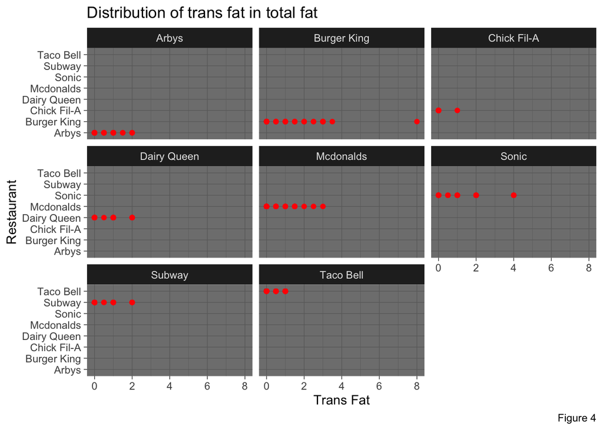

```r
ggplot(fastfood, aes(restaurant,trans_fat)) +
  geom_point(colour = "red") +
  facet_wrap(vars(restaurant)) +
  coord_flip() +
  labs(x = "Restaurant", y = "Trans Fat", title = "Distribution of trans fat in total fat", caption = "Figure 4") +
  theme_dark()
```

**23. Calculate and show the average (mean) `total_fat` for each type of restaurant. No need to save it as a variable.**

```r
fastfood %>%
  group_by(restaurant) %>%
  summarise(average_fat = mean(total_fat)) %>%
  ungroup() %>%
  kable()
```

| restaurant | average_fat |
| --- | --- |
| Arbys | 26.98182 |
| Burger King | 36.81429 |
| Chick Fil-A | 16.14815 |
| Dairy Queen | 28.85714 |
| Mcdonalds | 31.80702 |
| Sonic | 37.64151 |
| Subway | 18.47917 |
| Taco Bell | 20.89565 |

**24. And create a dataviz that allow to compare different restaurants on this variable (`total_fat`). You can present it on one dataviz (= no facets).**

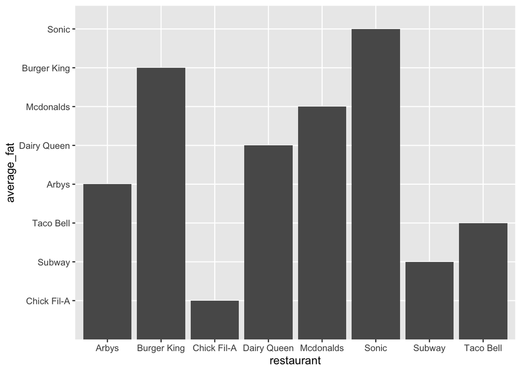

```r
fastfood %>%
  group_by(restaurant) %>%
  summarise(average_fat = mean(total_fat)) %>%
  ungroup() %>%
  mutate(average_fat = fct_reorder(restaurant, average_fat)) %>%
  ggplot(aes(restaurant,average_fat)) +
  geom_col()
```